# Modes of a Vibrating Building Under Sinusoidal Forcing

# Exercise: Forcing at the modal frequencies

Update the `frequency` value to simulate the fourth floor being forced at each of the four natural frequencies and note your observations. Compare the obeserved motion to the mode shapes associated with that modal frequency. Use the animation to help visualize what is happening.

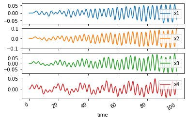

```python
sys.constants['frequency'] = ws[0]  # rad/s
traj = sys.forced_response(100)
traj[sys.coordinates.keys()].plot(subplots=True)
sys.animate_configuration(fps=10, repeat=False)
```

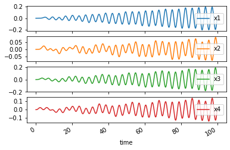

```python
sys.constants['frequency'] = ws[1]  # rad/s
traj = sys.forced_response(100)
traj[sys.coordinates.keys()].plot(subplots=True)
sys.animate_configuration(fps=10, repeat=False)
```

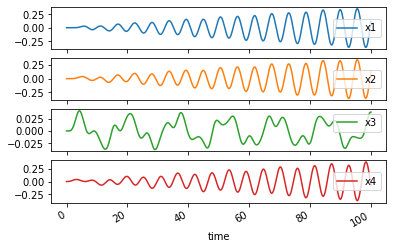

```python
sys.constants['frequency'] = ws[2]  # rad/s
traj = sys.forced_response(100)
traj[sys.coordinates.keys()].plot(subplots=True)
sys.animate_configuration(fps=10, repeat=False)
```

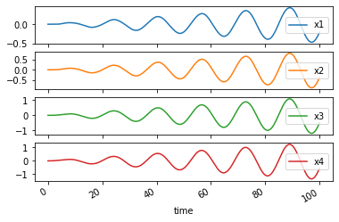

```python
sys.constants['frequency'] = ws[3]  # rad/s
traj = sys.forced_response(100)
traj[sys.coordinates.keys()].plot(subplots=True)
sys.animate_configuration(fps=10, repeat=False)
```

# Exercise: Forcing at a node

Recall that the 3rd mode shape has an eigenvector component that is zero:

```python
evecs
```

```
array([[ 0.42853,  0.65654, -0.57735,  0.22801],
       [-0.65654, -0.22801, -0.57735,  0.42853],
       [ 0.57735, -0.57735, -0.     ,  0.57735],
       [-0.22801,  0.42853,  0.57735,  0.65654]])
```

This is called a "node". This node is associated with $x_3$, the third floor and it tells us that there is no motion at floor 3 if this mode is excited.

Adjust the forcing function to apply sinusoidal forcing at the third floor. Use the third modal frequency to apply forcing to the third floor, then use one of the other modal frequencies to force the third floor. Compare the results and discuss your observations.

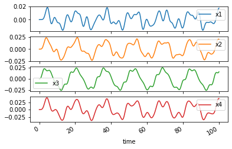

```python
sys.constants['frequency'] = ws[2]  # rad/s
def push_floor(amplitude, frequency, time):
    F1 = 0.0 if np.isscalar(time) else np.zeros_like(time)
    F2 = 0.0 if np.isscalar(time) else np.zeros_like(time)
    F3 = amplitude * np.sin(frequency * time)
    F4 = 0.0 if np.isscalar(time) else np.zeros_like(time)
    return F1, F2, F3, F4
sys.forcing_func = push_floor
traj = sys.forced_response(100)
traj[sys.coordinates.keys()].plot(subplots=True)
sys.animate_configuration(fps=10, repeat=False)
```

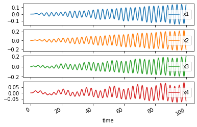

```python
sys.constants['frequency'] = ws[0]  # rad/s
def push_floor(amplitude, frequency, time):
    F1 = 0.0 if np.isscalar(time) else np.zeros_like(time)
    F2 = 0.0 if np.isscalar(time) else np.zeros_like(time)
    F3 = amplitude * np.sin(frequency * time)
    F4 = 0.0 if np.isscalar(time) else np.zeros_like(time)
    return F1, F2, F3, F4
sys.forcing_func = push_floor
traj = sys.forced_response(100)
traj[sys.coordinates.keys()].plot(subplots=True)
sys.animate_configuration(fps=10, repeat=False)
```